# Analiza techniczna funduszu opartego na ETF notowanych na GPW z wykorzystaniem długoterminowej strategii

### Pakiety

ten dokument wymaga poniższych pakietów

```r
#install.packages('devtools') # jeżeli konieczne

# przed zainstalowaniem "blotter/quantstrat" należy zainstalować
# obydwa poniższe pakiety

#install.packages('PerformanceAnalytics')
#install.packages('FinancialInstrument')

# devtools::install_github('braverock/blotter') # jeżeli konieczne
# devtools::install_github('braverock/quantstrat') # jeżeli konieczne

suppressPackageStartupMessages({
  library(quantmod)
  library(FinancialInstrument)
  library(PerformanceAnalytics)
  library(foreach)
  library(blotter)
  library(quantstrat)

#devtools::install_github('IlyaKipnis/IKTrading')
  library(IKTrading)
})
```

Suppresses warnings

```r
options("getSymbols.warning4.0" = FALSE)
```

Ustawienia strefy czasowej oraz waluty

```r
# czyszczenie procesora z ewentualnych strategii

# rm(list = ls(.blotter), envir = .blotter)

# Ustawienie waluty oraz strefy czasowej
currency("PLN")
```

```
## [1] "PLN"
```

```r
Sys.setenv(TZ = "UTC")
```

Pobieranie danych ze stooq.com i przekształcenie w format xts. Musimy je zapisywać na dysku przez funkcję *write.zoo()* ze względu na specyfikę dalszych analiz.

```r
W20L <- read.csv("f:/R_nauka/etfw20l_pl_d.csv")
# W20L <- select(W20L, -OpenInt) # dla kontraktów terminowych lepiej usunąć, psuje wykresy w "quantmod"
W20L <- tibble::add_column(W20L, Adjusted = W20L$Close) # to jest format dodawny przez yahoo.com.
# W polskich reliach = się cenie "Close"
head(W20L, 4)
```

|  | Date | Open | High | Low | Close | Volume | Adjusted |
| --- | --- | --- | --- | --- | --- | --- | --- |
| 1 | 2000-02-12 | 212.00 | 211.46 | 212.00 | 290.00 | NA | 290.00 |
| 2 | 2010-09-22 | 248.40 | 248.59 | 246.99 | 248.13 | 1861 | 248.13 |
| 3 | 2010-09-23 | 249.35 | 250.48 | 244.54 | 246.40 | 4552 | 246.40 |
| 4 | 2010-09-24 | 246.61 | 249.25 | 245.34 | 248.78 | 12244 | 248.78 |

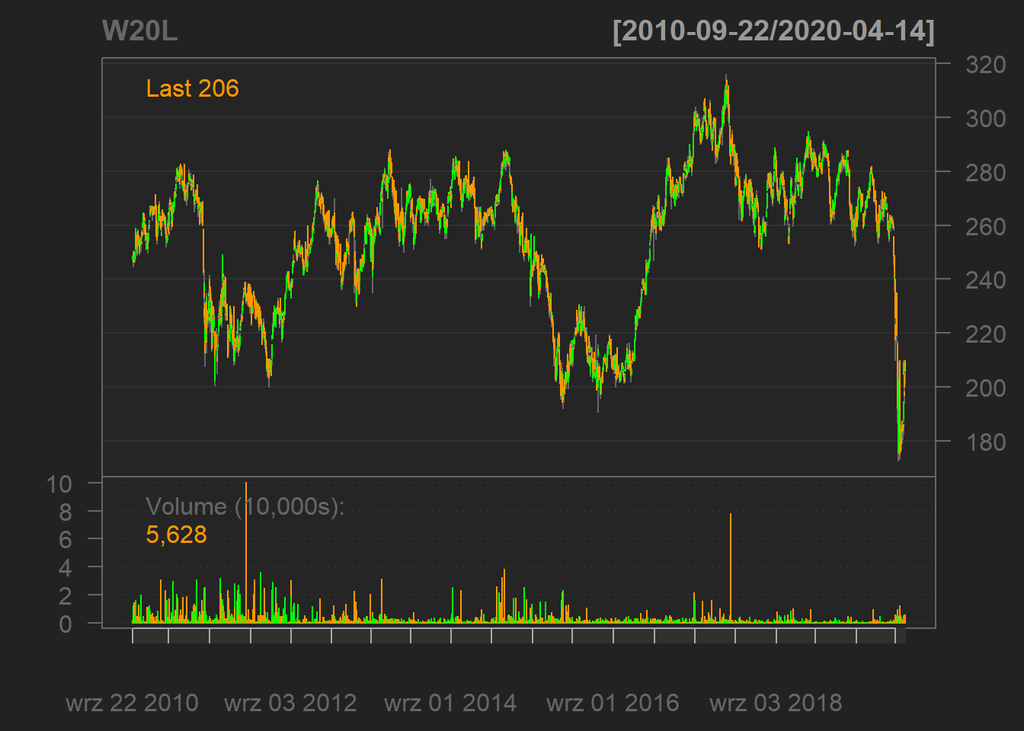

```r
W20L <- xts(W20L[,-1], order.by = as.Date(W20L[,1]))
names(W20L) = c("W20L.Open", "W20L.High", "W20L.Low", "W20L.Close", "W20L.Volume", "W20L.Adjusted")
chartSeries(W20L)
```

```r
write.zoo(W20L, file = "f:/R_nauka/W20L.csv", sep = ",")

DAX <- read.csv("f:/R_nauka/etfdax_pl_d.csv")
DAX <- tibble::add_column(DAX, Adjusted = DAX$Close)
head(DAX, 4)
```

|  | Date | Open | High | Low | Close | Volume | Adjusted |
| --- | --- | --- | --- | --- | --- | --- | --- |
| 1 | 2000-04-26 | 429.18 | 425.76 | 429.18 | 515.0 | NA | 515.0 |
| 2 | 2011-05-31 | 282.10 | 283.40 | 282.10 | 283.0 | 91 | 283.0 |
| 3 | 2011-06-01 | 300.00 | 300.00 | 280.10 | 280.1 | 406 | 280.1 |
| 4 | 2011-06-02 | 298.60 | 298.60 | 275.60 | 275.6 | 64 | 275.6 |

```r
tail(DAX, 4)
```

|  | Date | Open | High | Low | Close | Volume | Adjusted |
| --- | --- | --- | --- | --- | --- | --- | --- |
| 2090 | 2020-04-07 | 448.6 | 457.00 | 440.00 | 441.40 | 5012 | 441.40 |
| 2091 | 2020-04-08 | 440.8 | 442.45 | 436.50 | 440.50 | 1203 | 440.50 |
| 2092 | 2020-04-09 | 448.4 | 455.20 | 444.45 | 452.30 | 1313 | 452.30 |
| 2093 | 2020-04-14 | 461.7 | 480.00 | 457.00 | 461.65 | 1764 | 461.65 |

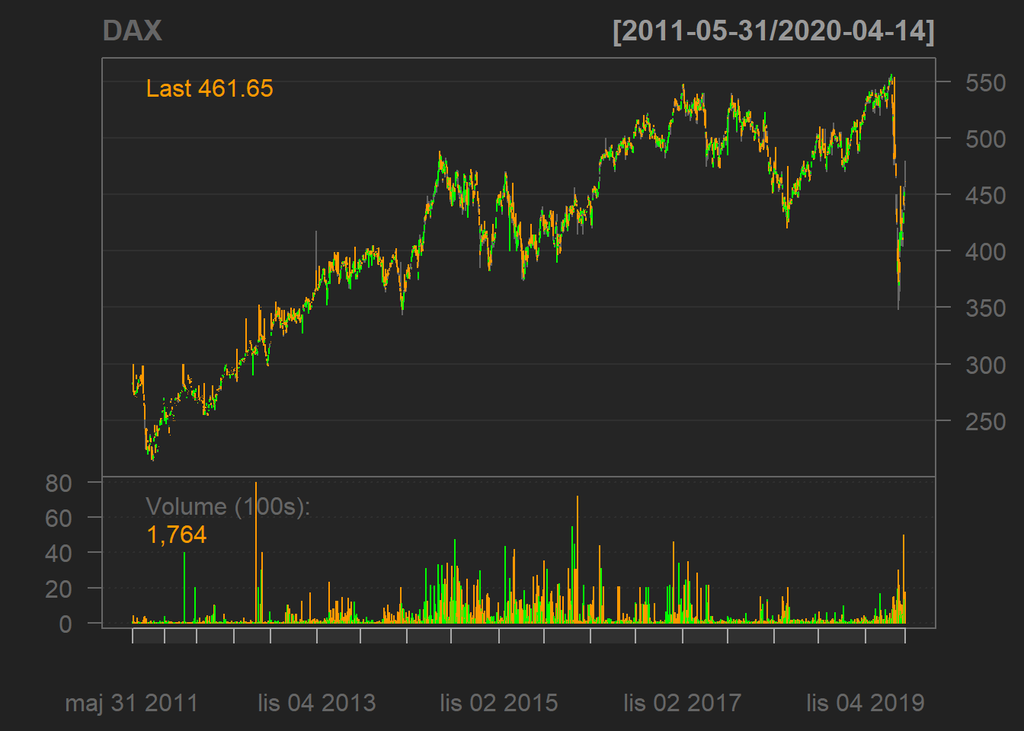

```r
DAX <- xts(DAX[,-1], order.by = as.Date(DAX[,1]))
names(DAX) = c("DAX.Open", "DAX.High", "DAX.Low", "DAX.Close", "DAX.Volume", "DAX.Adjusted")
chartSeries(DAX)
```

```r
write.zoo(DAX, file = "f:/R_nauka/DAX.csv", sep = ",")

SPY_1 <- read.csv("f:/R_nauka/etfsp500_pl_d.csv")
SPY_1 <- tibble::add_column(SPY_1, Adjusted = SPY_1$Close)
head(SPY_1, 4)
```

|  | Date | Open | High | Low | Close | Volume | Adjusted |
| --- | --- | --- | --- | --- | --- | --- | --- |
| 1 | 2011-05-31 | 34.820 | 34.820 | 32.540 | 32.540 | 366 | 32.540 |
| 2 | 2011-06-01 | 35.667 | 35.667 | 32.315 | 32.315 | 4047 | 32.315 |
| 3 | 2011-06-02 | 34.545 | 34.545 | 31.948 | 31.948 | 3030 | 31.948 |
| 4 | 2011-06-03 | 31.652 | 31.652 | 31.329 | 31.329 | 28 | 31.329 |

```r
tail(SPY_1)
```

|  | Date | Open | High | Low | Close | Volume | Adjusted |
| --- | --- | --- | --- | --- | --- | --- | --- |
| 2137 | 2020-04-03 | 108.56 | 109.90 | 108.12 | 109.04 | 2901 | 109.04 |
| 2138 | 2020-04-06 | 112.00 | 113.38 | 111.50 | 113.00 | 3490 | 113.00 |
| 2139 | 2020-04-07 | 115.18 | 117.76 | 115.00 | 115.58 | 14366 | 115.58 |
| 2140 | 2020-04-08 | 114.00 | 117.32 | 113.00 | 115.66 | 5569 | 115.66 |
| 2141 | 2020-04-09 | 117.66 | 119.66 | 116.78 | 119.10 | 5649 | 119.10 |
| 2142 | 2020-04-14 | 120.10 | 120.80 | 119.10 | 120.10 | 14286 | 120.10 |

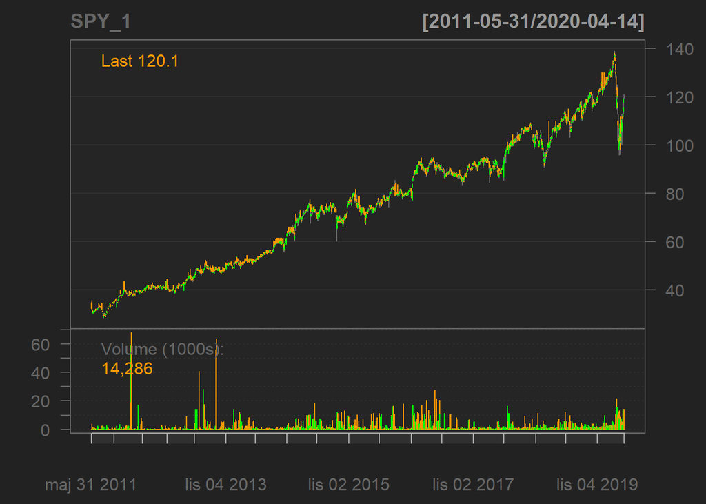

```r
SPY_1 <- xts(SPY_1[,-1], order.by = as.Date(SPY_1[,1]))
names(SPY_1) = c("SPY_1.Open", "SPY_1.High", "SPY_1.Low", "SPY_1.Close", "SPY_1.Volume", "SPY_1.Adjusted")
chartSeries(SPY_1)
```

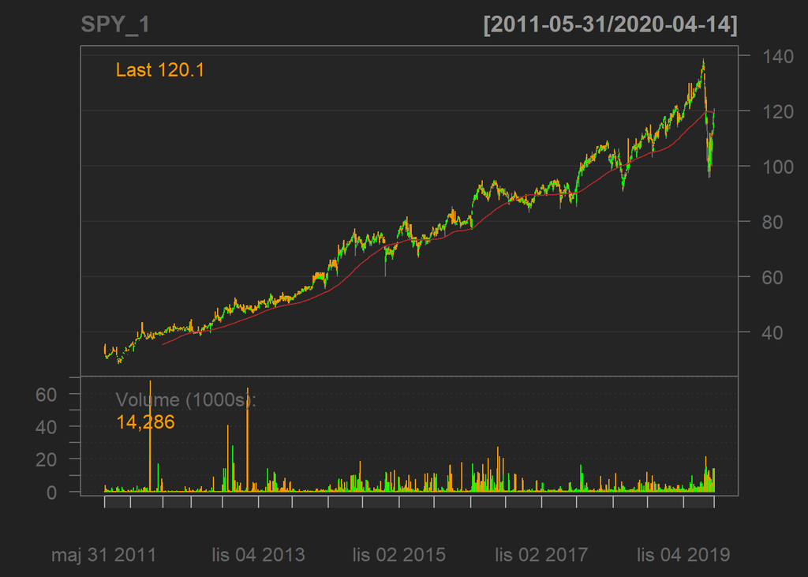

```r
addSMA(200)
```

```r
write.zoo(SPY_1, file = "f:/R_nauka/SPY_1.csv", sep = ",")

#setDefaults(getSymbols, src = 'csv') # trzeba prze zrodło 'csv'
```

Określenie aktywów przeznaczonych do analizy

```r
symbols <- c("DAX", #ETF DAX
             "SPY_1", #ETF SP500
             "W20L") #ETF Wig20 Long
```

ETF z GPW ponowne zaciągnięcie danych już wcześniej przekształconych i zapisanych na dysku

```r
suppressMessages(getSymbols(symbols, from = '2000-01-01', dir = "f:/R_nauka/",
                            to = Sys.Date(),  src = "csv", adjust = TRUE))
```

```
## [1] "DAX"   "SPY_1" "W20L"
```

Nadanie nazw, wykorzystywanych w dalszej pracy

```r
stock(symbols, currency = "PLN", multiplier = 1)
```

```
## [1] "DAX"   "SPY_1" "W20L"
```

```r
str(W20L)
```

```
## An 'xts' object on 2000-02-12/2020-04-14 containing:
##   Data: num [1:2385, 1:6] 212 248 249 247 250 ...
##  - attr(*, "dimnames")=List of 2
##   ..$ : NULL
##   ..$ : chr [1:6] "W20L.Open" "W20L.High" "W20L.Low" "W20L.Close" ...
##   Indexed by objects of class: [Date] TZ: UTC
##   xts Attributes:
## List of 2
##  $ src    : chr "csv"
##  $ updated: POSIXct[1:1], format: "2020-06-16 20:14:18"
```

```r
str(DAX)
```

```
## An 'xts' object on 2000-04-26/2020-04-14 containing:
##   Data: num [1:2093, 1:6] 429 282 300 299 276 ...
##  - attr(*, "dimnames")=List of 2
##   ..$ : NULL
##   ..$ : chr [1:6] "DAX.Open" "DAX.High" "DAX.Low" "DAX.Close" ...
##   Indexed by objects of class: [Date] TZ: UTC
##   xts Attributes:
## List of 2
##  $ src    : chr "csv"
##  $ updated: POSIXct[1:1], format: "2020-06-16 20:14:18"
```

```r
str(SPY_1)
```

```
## An 'xts' object on 2011-05-31/2020-04-14 containing:
##   Data: num [1:2142, 1:6] 34.8 35.7 34.5 31.7 31.3 ...
##  - attr(*, "dimnames")=List of 2
##   ..$ : NULL
##   ..$ : chr [1:6] "SPY_1.Open" "SPY_1.High" "SPY_1.Low" "SPY_1.Close" ...
##   Indexed by objects of class: [Date] TZ: UTC
##   xts Attributes:
## List of 2
##  $ src    : chr "csv"
##  $ updated: POSIXct[1:1], format: "2020-06-16 20:14:18"
```

wykres korelacji logarytmowanych stóp zwrotu oraz tabela korelacji

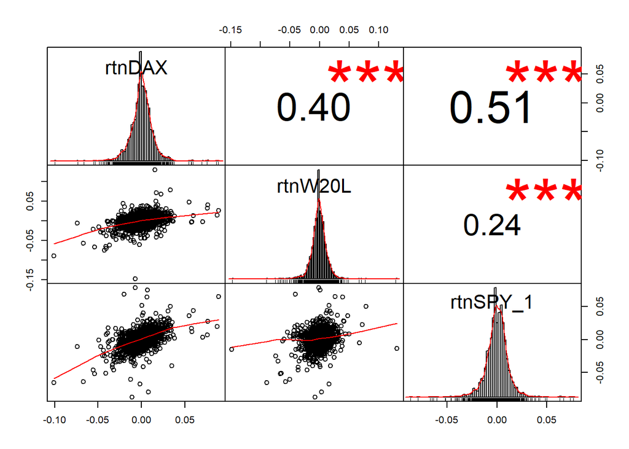

```r
data<-cbind( diff(log(Cl(DAX))),   diff(log(Cl(W20L))),  diff(log(Cl(SPY_1))))
data <- na.omit(data)
names(data) = c("rtnDAX", "rtnW20L", "rtnSPY_1")

#str(data)
#View(data)

chart.Correlation(data)
```

```r
table.cor <- table.Correlation(data$rtnW20L, data)
knitr::kable(table.cor)
```

|  | Correlation | p-value | Lower CI | Upper CI |
| --- | --- | --- | --- | --- |
| rtnW20L to rtnDAX | 0.4018678 | 0 | 0.3648502 | 0.4376170 |
| rtnW20L to rtnW20L | 1.0000000 | 0 | 1.0000000 | 1.0000000 |
| rtnW20L to rtnSPY_1 | 0.2414406 | 0 | 0.2001591 | 0.2818663 |

histogramy zlogarytmowanych stóp zwrotu badanych aktywów

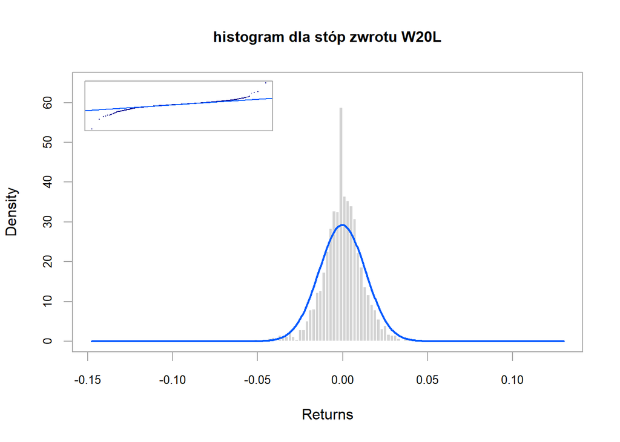

```r
chart.Histogram(data$rtnW20L, probability = TRUE, main = "histogram dla stóp zwrotu W20L",
                methods = c("add.normal", "add.qqplot"))
```

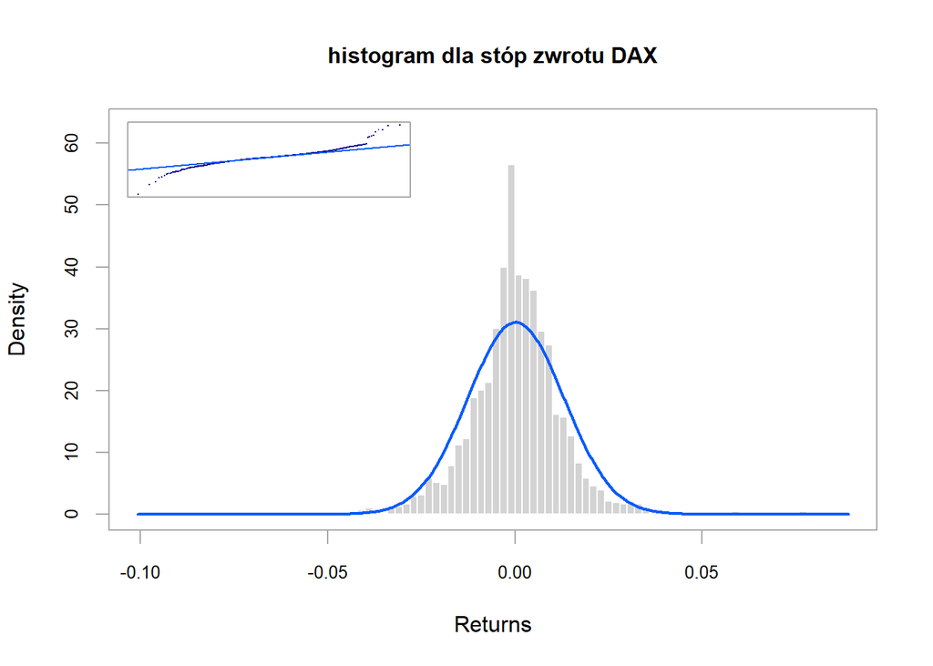

```r
chart.Histogram(data$rtnDAX, probability = TRUE, main = "histogram dla stóp zwrotu DAX",
                methods = c("add.normal", "add.qqplot"))
```

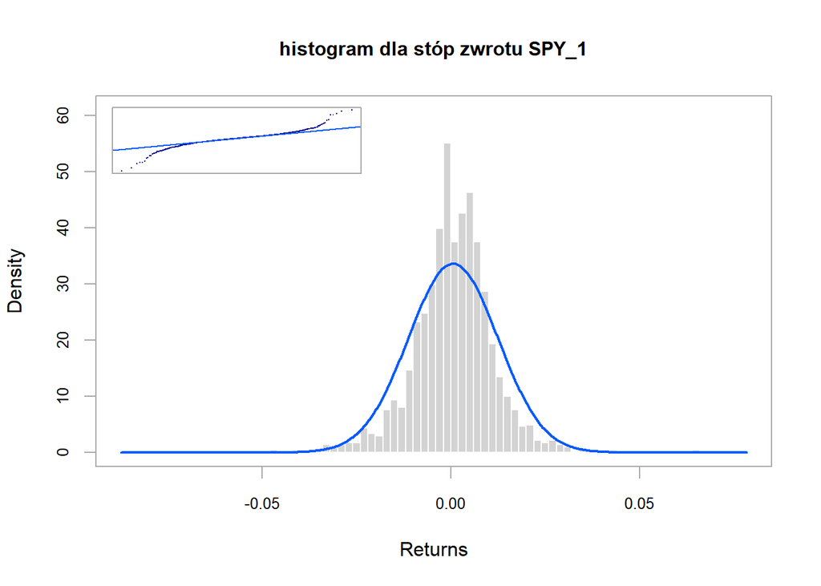

```r
chart.Histogram(data$rtnSPY_1, probability = TRUE, main = "histogram dla stóp zwrotu SPY_1",
                methods = c("add.normal", "add.qqplot"))
```

modele regresji pomiędzy zlogarytmowanymi stopami zwrotów

```r
library(ggplot2)
fit_1 <- lm(rtnW20L ~ rtnDAX, data = data)
summary(fit_1)
```

```
##
## Call:
## lm(formula = rtnW20L ~ rtnDAX, data = data)
##
## Residuals:
##       Min        1Q    Median        3Q       Max
## -0.144523 -0.006179  0.000233  0.006355  0.123854
##
## Coefficients:
##               Estimate Std. Error t value Pr(>|t|)
## (Intercept) -0.0003393  0.0002765  -1.227     0.22
## rtnDAX       0.4264330  0.0215132  19.822   <2e-16 ***
## ---
## Signif. codes:  0 '***' 0.001 '**' 0.01 '*' 0.05 '.' 0.1 ' ' 1
##
## Residual standard error: 0.01249 on 2040 degrees of freedom
## Multiple R-squared:  0.1615, Adjusted R-squared:  0.1611
## F-statistic: 392.9 on 1 and 2040 DF,  p-value: < 2.2e-16
```

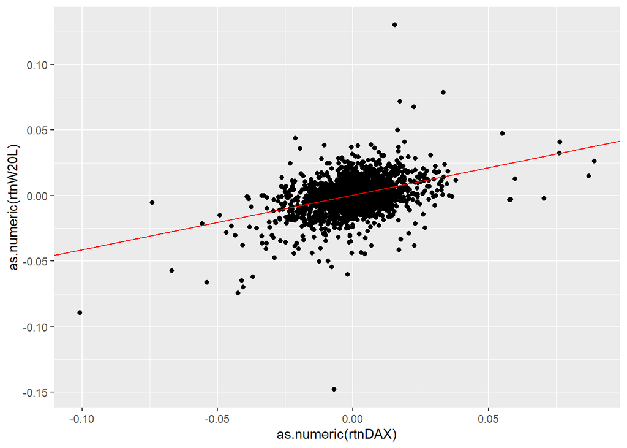

```r
ggplot(data = data, aes( x = as.numeric(rtnDAX), y = as.numeric(rtnW20L))) +
  geom_point() +
  geom_abline(intercept = 0.0004, slope = 0.418, colour = "red")
```

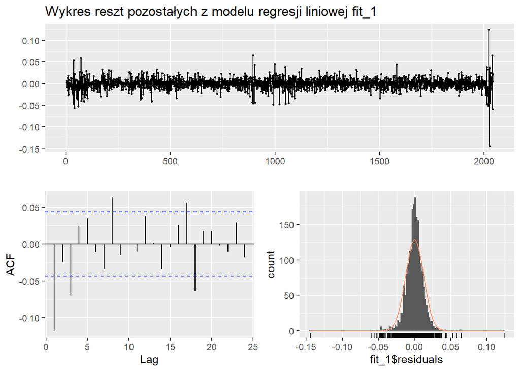

```r
# ggplot(data = data, aes( x = as.numeric(rtnDAX), y = as.numeric(rtnW20L))) +
#   geom_point() +
#   geom_smooth()
forecast::ggtsdisplay(fit_1$residuals, plot.type = "histogram", lag.max = 24,
                    main = "Wykres reszt pozostałych z modelu regresji liniowej fit_1") # dopasowanie reszt rtnDAX vs. rtnW20L
```

```r
data_lag <- data
data_lag$rtnW20L_lag1 <- lag(data$rtnW20L)
data_lag$rtnDAX_lag1 <- lag(data$rtnDAX)
data_lag$rtnW20L_lag3 <- lag(data$rtnW20L, 3)
fit_1lag <- lm(rtnW20L ~ rtnDAX + rtnW20L_lag1 + rtnDAX_lag1 + rtnW20L_lag3, data = data_lag)
summary(fit_1lag)
```

```
##
## Call:
## lm(formula = rtnW20L ~ rtnDAX + rtnW20L_lag1 + rtnDAX_lag1 +
##     rtnW20L_lag3, data = data_lag)
##
## Residuals:
##       Min        1Q    Median        3Q       Max
## -0.132618 -0.006095  0.000229  0.006388  0.122747
##
## Coefficients:
##                Estimate Std. Error t value Pr(>|t|)
## (Intercept)  -0.0004210  0.0002742  -1.535  0.12483
## rtnDAX        0.4425828  0.0214393  20.644  < 2e-16 ***
## rtnW20L_lag1 -0.1215196  0.0220403  -5.514 3.97e-08 ***
## rtnDAX_lag1   0.1110502  0.0233353   4.759 2.08e-06 ***
## rtnW20L_lag3 -0.0627899  0.0202297  -3.104  0.00194 **
## ---
## Signif. codes:  0 '***' 0.001 '**' 0.01 '*' 0.05 '.' 0.1 ' ' 1
##
## Residual standard error: 0.01237 on 2034 degrees of freedom
##   (3 observations deleted due to missingness)
## Multiple R-squared:  0.1804, Adjusted R-squared:  0.1788
## F-statistic:   112 on 4 and 2034 DF,  p-value: < 2.2e-16
```

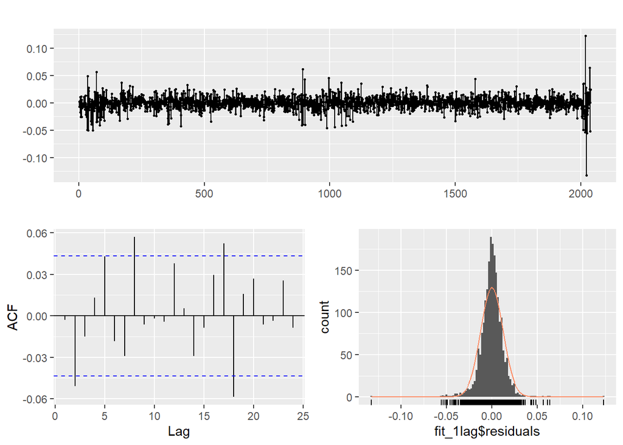

```r
forecast::ggtsdisplay(fit_1lag$residuals, plot.type = "histogram", lag.max = 24 )
```

```r
fit_4 <- lm(rtnDAX ~ rtnSPY_1 , data = data)
summary(fit_4)
```

```
##
## Call:
## lm(formula = rtnDAX ~ rtnSPY_1, data = data)
##
## Residuals:
##       Min        1Q    Median        3Q       Max
## -0.067961 -0.005332  0.000243  0.005379  0.076162
##
## Coefficients:
##               Estimate Std. Error t value Pr(>|t|)
## (Intercept) -0.0001041  0.0002442  -0.426     0.67
## rtnSPY_1     0.5573020  0.0205465  27.124   <2e-16 ***
## ---
## Signif. codes:  0 '***' 0.001 '**' 0.01 '*' 0.05 '.' 0.1 ' ' 1
##
## Residual standard error: 0.01102 on 2040 degrees of freedom
## Multiple R-squared:  0.2651, Adjusted R-squared:  0.2647
## F-statistic: 735.7 on 1 and 2040 DF,  p-value: < 2.2e-16
```

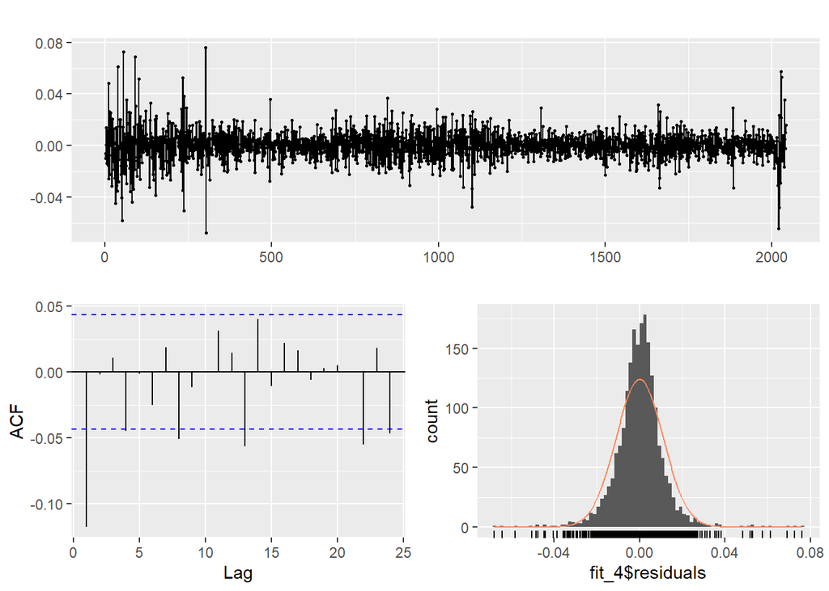

```r
forecast::ggtsdisplay(fit_4$residuals, plot.type = "histogram", lag.max = 24) # dopasowanie reszt rtnDAX vs. rtnSPY_1
```

```r
data_lag$rtnSPY_1_lag1 <- lag(data$rtnSPY_1)
fit_5 <- lm(rtnDAX ~ rtnSPY_1 + rtnDAX_lag1 + rtnSPY_1_lag1, data = data_lag)
summary(fit_5)
```

```
##
## Call:
## lm(formula = rtnDAX ~ rtnSPY_1 + rtnDAX_lag1 + rtnSPY_1_lag1,
##     data = data_lag)
##
## Residuals:
##       Min        1Q    Median        3Q       Max
## -0.065523 -0.005423  0.000168  0.005489  0.076143
##
## Coefficients:
##                 Estimate Std. Error t value Pr(>|t|)
## (Intercept)   -0.0001775  0.0002420  -0.733    0.463
## rtnSPY_1       0.5781669  0.0205608  28.120  < 2e-16 ***
## rtnDAX_lag1   -0.1199322  0.0220160  -5.448 5.73e-08 ***
## rtnSPY_1_lag1  0.1551912  0.0239745   6.473 1.20e-10 ***
## ---
## Signif. codes:  0 '***' 0.001 '**' 0.01 '*' 0.05 '.' 0.1 ' ' 1
##
## Residual standard error: 0.0109 on 2037 degrees of freedom
##   (1 observation deleted due to missingness)
## Multiple R-squared:  0.2818, Adjusted R-squared:  0.2807
## F-statistic: 266.4 on 3 and 2037 DF,  p-value: < 2.2e-16
```

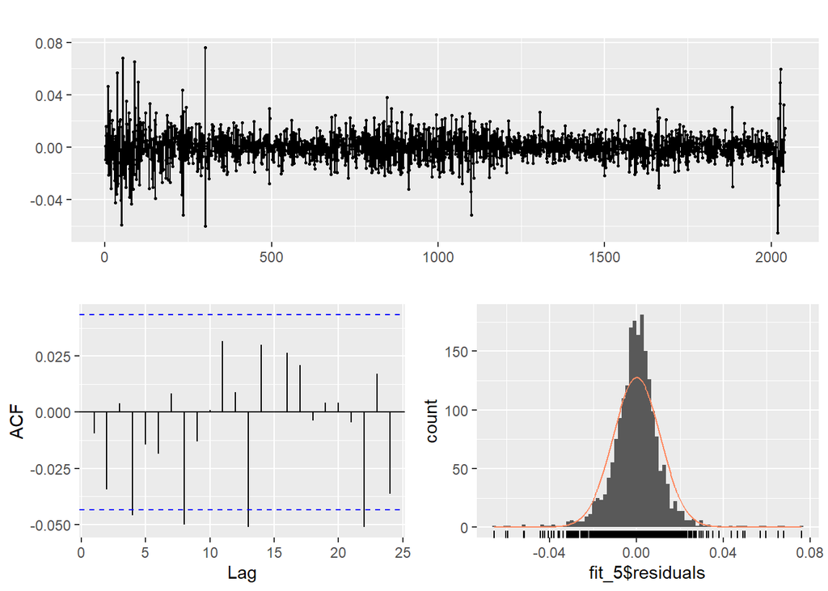

```r
forecast::ggtsdisplay(fit_5$residuals, plot.type = "histogram", lag.max = 24)
```

##strategia podążania za trendem “CLENOW SIMPLE”

Podstawowe parametry: zakres dat, ważne aby *initDate=* była wczesniej niż *from=*

```r
initDate = '2010-01-01'
from = '2011-01-01'
to = Sys.Date()
options(width = 70)
```

wartosc i wielkosc poczatkowej pozycji

```r
tradeSize <- 100000
initEq <- tradeSize * length(symbols)

strategy.st <- "Clenow_Simple"
portfolio.st <- "Clenow_Simple"
account.st <- "Clenow_Simple"
```

Należy pamietać aby wyczyścić procesor jeżeli może mieć w pamięci poprzednio analizowaną strategię. Równocześnie ponownie wprowadzić ponownie środowisko pakietu **blotter**

```r
#rm.strat(portfolio.st)
#rm.strat(strategy.st)
#if(!exists(".blotter")) .blotter <<- new.env()
```

Ustawienie parametrów początkowych

```r
initPortf(portfolio.st, symbols = symbols,
          initDate = initDate, currency = 'PLN')
```

```
## [1] "Clenow_Simple"
```

```r
initAcct(account.st, portfolios = portfolio.st,
         initDate = initDate, currency = 'PLN', initEq = initEq)
```

```
## [1] "Clenow_Simple"
```

```r
initOrders(portfolio.st, initDate = initDate)
strategy(strategy.st, store=TRUE)
```

# Backtest CLENOW SIMPLE

indykatory

```r
nLag = 252
pctATR = 0.02
period = 10

namedLag <- function(x, k = 1, na.pad = TRUE, ...) { # oblicza wartość łączącą warunki -252dniowe opóźnienie
                                                     # -utworzy wynik w dodatkowej kolumnie
  out <- lag(x, k = k, na.pad = na.pad, ...)
  out[is.na(out)] <- x[is.na(out)]
  colnames(out) <- "namedLag"
  return(out)
}
```

Dodawanie wskaźników do strategii

```r
add.indicator(strategy.st, name = "namedLag",
              arguments = list(x = quote(Cl(mktdata)), k = nLag),
              label = "ind")
```

```
## [1] "Clenow_Simple"
```

```r
add.indicator(strategy.st, name = "lagATR", # z pakietu IKTrading zwraca wartość opóźnionego ATR(n=period)
              arguments = list(HLC = quote(HLC(mktdata)), n = period),
              label = "atrX")
```

```
## [1] "Clenow_Simple"
```

```r
test <- applyIndicators(strategy.st, mktdata = OHLC(W20L))
head(round(test, 2),6)
```

```
##            W20L.Open W20L.High W20L.Low W20L.Close namedLag.ind
## 2000-02-12    212.00    211.46   212.00     290.00       290.00
## 2010-09-22    248.40    248.59   246.99     248.13       248.13
## 2010-09-23    249.35    250.48   244.54     246.40       246.40
## 2010-09-24    246.61    249.25   245.34     248.78       248.78
## 2010-09-27    250.19    250.38   248.78     248.78       248.78
## 2010-09-28    247.27    248.12   246.33     246.33       246.33
##            atr.atrX
## 2000-02-12       NA
## 2010-09-22       NA
## 2010-09-23       NA
## 2010-09-24       NA
## 2010-09-27       NA
## 2010-09-28       NA
```

dodawanie sygnałów do strategii

```r
add.signal(strategy.st, name = "sigCrossover",
           arguments = list(columns = c("Close", "namedLag.ind"),
                            relationship = "gt"),
           label = "coverOrBuy")
```

```
## [1] "Clenow_Simple"
```

```r
add.signal(strategy.st, name = "sigCrossover",
           arguments = list(columns = c("Close", "namedLag.ind"),
                            relationship = "lt"),
           label = "sellOrShort")
```

```
## [1] "Clenow_Simple"
```

dodawanie warunków dla pozycji długiej(kupno)

```r
add.rule(strategy.st, name = "ruleSignal",
         arguments = list(sigcol = "coverOrBuy",
                          sigval = TRUE, ordertype = "market",
                          orderside = "long", replace = FALSE,
                          prefer = "Open", osFUN = osDollarATR,
                          tradeSize = tradeSize, pctATR = pctATR,
                          atrMod = "X"), type = "enter", path.dep = TRUE)
```

```
## [1] "Clenow_Simple"
```

```r
add.rule(strategy.st, name = "ruleSignal",
         arguments = list(sigcol = "sellOrShort",
                          sigval = TRUE, orderqty = "all",
                          ordertype = "market", orderside = "long",
                          replace = FALSE, prefer = "Open"),
         type = "exit", path.dep = TRUE)
```

```
## [1] "Clenow_Simple"
```

dodawanie warunków dla pozycji krótkiej(sprzedaż)

```r
add.rule(strategy.st, name = "ruleSignal",
         arguments = list(sigcol = "sellOrShort",
                          sigval = TRUE, ordertype = "market",
                          orderside = "short", replace = FALSE,
                          prefer = "Open", osFUN = osDollarATR,
                          tradeSize = -tradeSize, pctATR = pctATR,
                          atrMod = "X"), type = "enter", path.dep = TRUE)
```

```
## [1] "Clenow_Simple"
```

```r
add.rule(strategy.st, name = "ruleSignal",
         arguments = list(sigcol = "coverOrBuy",
                          sigval = TRUE, orderqty = "all",
                          ordertype = "market", orderside = "short",
                          replace = FALSE, prefer = "Open"),
         type = "exit", path.dep = TRUE)
```

```
## [1] "Clenow_Simple"
```

# uruchomienie analizy

```r
t1 <- Sys.time()
out <- applyStrategy(strategy = strategy.st,
                     portfolios = portfolio.st)
```

```
## [1] "2012-09-21 00:00:00 DAX -709 @ 298.5"
## [1] "2012-09-25 00:00:00 DAX 709 @ 299.8"
## [1] "2012-09-25 00:00:00 DAX 755 @ 299.8"
## [1] "2014-10-16 00:00:00 DAX -755 @ 349.43"
## [1] "2014-10-16 00:00:00 DAX -299 @ 349.43"
## [1] "2014-10-20 00:00:00 DAX 299 @ 360"
## [1] "2014-10-20 00:00:00 DAX 279 @ 360"
## [1] "2015-09-23 00:00:00 DAX -279 @ 390.35"
## [1] "2015-09-23 00:00:00 DAX -275 @ 390.35"
## [1] "2015-09-28 00:00:00 DAX 275 @ 395"
## [1] "2015-09-28 00:00:00 DAX 246 @ 395"
## [1] "2015-09-29 00:00:00 DAX -246 @ 382.52"
## [1] "2015-09-29 00:00:00 DAX -234 @ 382.52"
## [1] "2015-10-01 00:00:00 DAX 234 @ 399.97"
## [1] "2015-10-01 00:00:00 DAX 240 @ 399.97"
```

[output cut: 288 more lines]

Czas obliczeń. Przy rozbudowanym portfelu może trwać kilkanaście minut

```r
t2 <- Sys.time()
print(t2 - t1)
```

```
## Time difference of 3.006224 secs
```

Ocena wydajności strategii

```r
updatePortf(portfolio.st)
```

```
## [1] "Clenow_Simple"
```

```r
dateRange <- time(getPortfolio(portfolio.st)$summary)[-1]
updateAcct(portfolio.st, dateRange)
```

```
## [1] "Clenow_Simple"
```

```r
updateEndEq(account.st)
```

```
## [1] "Clenow_Simple"
```

```r
tStats <- tradeStats(Portfolios = portfolio.st, use = "trades",
                     inclZeroDays = FALSE)
tStats[, 4:ncol(tStats)] <- round(tStats[, 4:ncol(tStats)], 2)

knitr::kable(data.frame(t(tStats[,-c(1,2)])))
```

|  | DAX | SPY_1 | W20L |
| --- | --- | --- | --- |
| Num.Txns | 81.00 | 85.00 | 137.00 |
| Num.Trades | 41.00 | 43.00 | 69.00 |
| Net.Trading.PL | -54088.80 | 94331.97 | 73430.24 |
| Avg.Trade.PL | -1319.24 | 2193.77 | 1064.21 |
| Med.Trade.PL | -1395.56 | -906.53 | -489.06 |
| Largest.Winner | 37470.65 | 103153.93 | 33417.16 |
| Largest.Loser | -28953.60 | -15480.13 | -7837.30 |
| Gross.Profits | 65247.74 | 173169.18 | 161468.02 |
| Gross.Losses | -119336.54 | -78837.21 | -88037.78 |
| Std.Dev.Trade.PL | 8360.17 | 17271.29 | 7918.20 |
| Std.Err.Trade.PL | 1305.64 | 2633.85 | 953.24 |
| Percent.Positive | 21.95 | 30.23 | 39.13 |
| Percent.Negative | 78.05 | 69.77 | 60.87 |
| Profit.Factor | 0.55 | 2.20 | 1.83 |
| Avg.Win.Trade | 7249.75 | 13320.71 | 5980.30 |
| Med.Win.Trade | 2535.46 | 2617.08 | 2207.80 |
| Avg.Losing.Trade | -3729.27 | -2627.91 | -2096.14 |
| Med.Losing.Trade | -2163.80 | -1879.16 | -1675.22 |
| Avg.Daily.PL | -1279.50 | 2155.05 | 393.64 |
| Med.Daily.PL | -1337.15 | -996.77 | -506.66 |
| Std.Dev.Daily.PL | 8462.75 | 17478.76 | 5669.58 |
| Std.Err.Daily.PL | 1338.08 | 2697.03 | 687.54 |
| Ann.Sharpe | -2.40 | 1.96 | 1.10 |
| Max.Drawdown | -132019.30 | -52885.79 | -46142.19 |
| Profit.To.Max.Draw | -0.41 | 1.78 | 1.59 |
| Avg.WinLoss.Ratio | 1.94 | 5.07 | 2.85 |
| Med.WinLoss.Ratio | 1.17 | 1.39 | 1.32 |
| Max.Equity | 77930.50 | 137649.30 | 96574.34 |
| Min.Equity | -54088.80 | -8308.43 | -23935.13 |
| End.Equity | -54088.80 | 94331.97 | 73430.24 |

```r
aggPF <- sum(tStats$Gross.Profits) / -sum(tStats$Gross.Losses)
aggCorrect <- mean(tStats$Percent.Positive)
numTrades <- sum(tStats$Num.Trades)
meanAvgWLR <- mean(tStats$Avg.WinLoss.Ratio[tStats$Avg.WinLoss.Ratio < Inf], na.rm = TRUE)
aggEnd.Equity <- sum(tStats$End.Equity) + 100000

table_1 <- data.frame(Items = c("współczynnik zysku/straty ", "średnia z zyskownych",
                                "ilość transakcji", "średnia wartość zysk/strata",
                                "wartość końcowa portfela"),
                      Features = c(aggPF, aggCorrect, numTrades,
                                   meanAvgWLR, aggEnd.Equity))
knitr::kable(table_1, digits = 2)
```

| Items | Features |
| --- | --- |
| współczynnik zysku/straty | 1.40 |
| średnia z zyskownych | 30.44 |
| ilość transakcji | 153.00 |
| średnia wartość zysk/strata | 3.29 |
| wartość końcowa portfela | 213673.41 |

Uśrednianie stopy zwroru z aktywów portfela oraz konwertowanie na format *xts*

```r
instRets <- PortfReturns(account.st)
portfRets <- xts(rowMeans(instRets) * ncol(instRets),
                 order.by = index(instRets))
portfRets <- portfRets[!is.na(portfRets)]
```

Skumulowana stopa zwrotu oraz okreslenie pierwszego dnia, w którym wartość > 0 w celu porównania w dalszych analizach z wykresem odniesienia

```r
cumPortfRets <- cumprod(1 + portfRets)
firstNonZeroDay <- as.character(index(portfRets)[
  min(which(portfRets != 0))])
```

wykresy zlogarytmowanych stóp zwrotu portfela: histogram, wykres reszt, autokorelacji

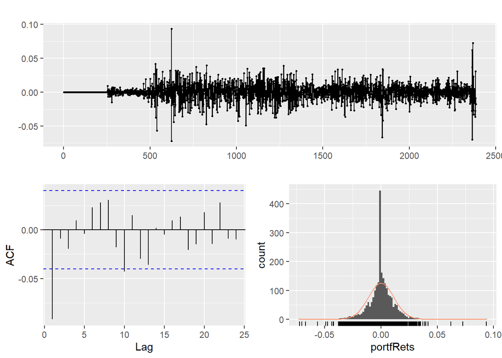

```r
forecast::ggtsdisplay(portfRets, plot.type = "histogram", lag.max = 24)
```

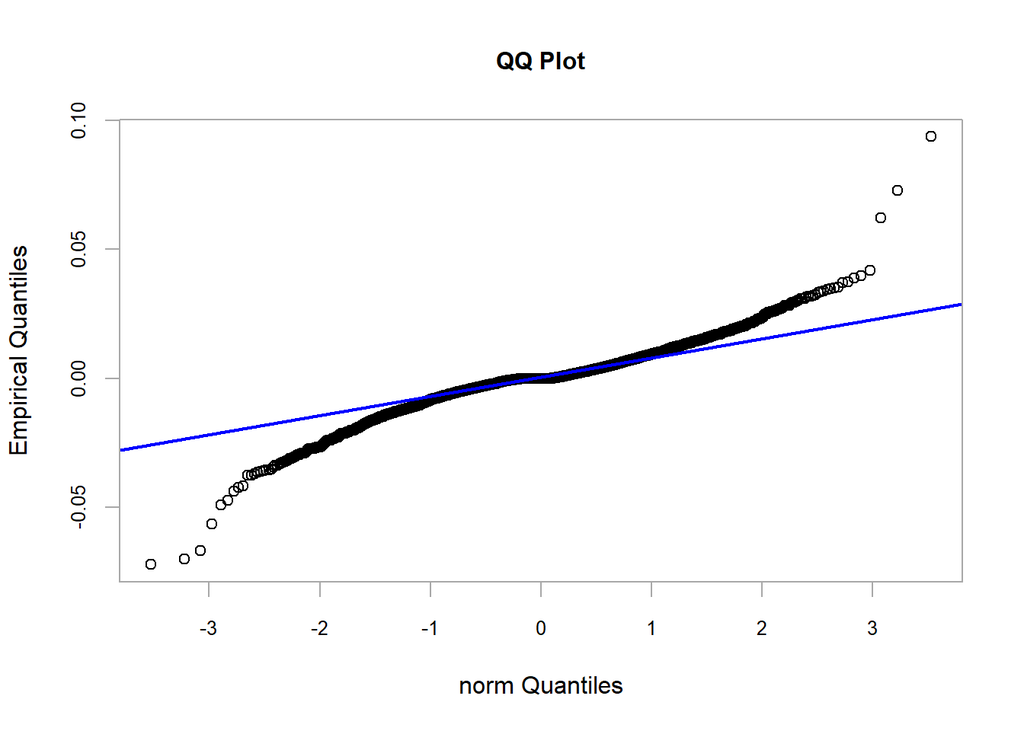

```r
chart.QQPlot(portfRets, distribution = "norm")
```

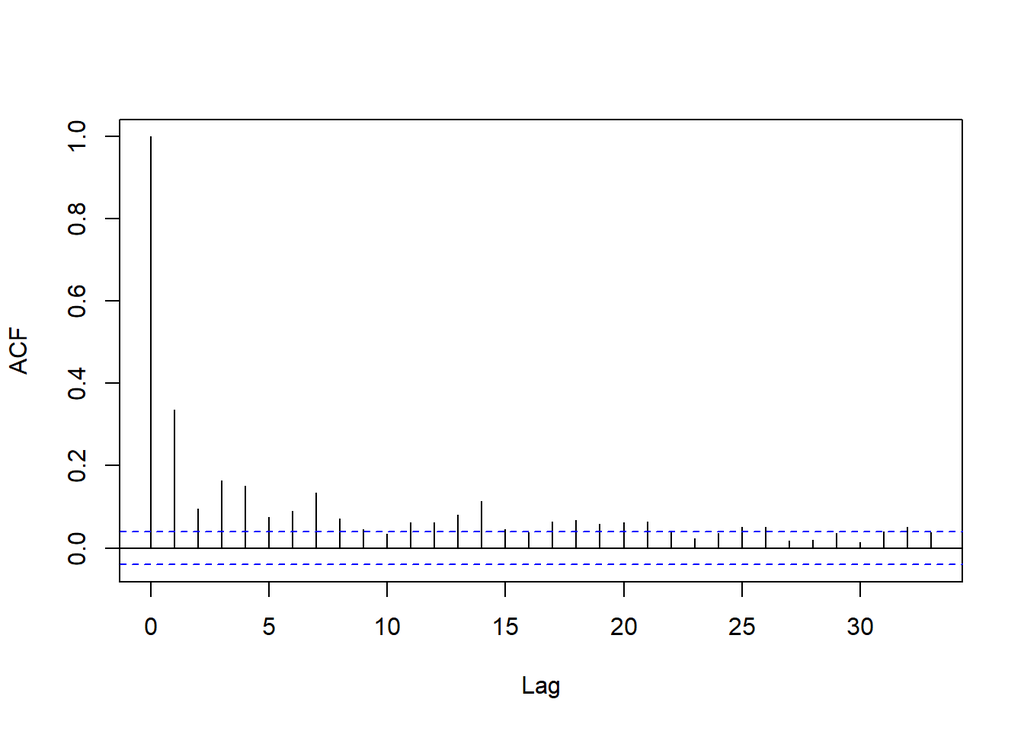

```r
acf(portfRets^2, main = "")
```

#Model GARCH

Dopasowania modelu

```r
library(fGarch)
fit_4 <- garchFit(~ 1 + garch(1 , 1), data = portfRets, trace = FALSE) #dla rozkładu normalnego
summary(fit_4)
```

```
##
## Title:
##  GARCH Modelling
##
## Call:
##  garchFit(formula = ~1 + garch(1, 1), data = portfRets, trace = FALSE)
##
## Mean and Variance Equation:
##  data ~ 1 + garch(1, 1)
## <environment: 0x0000000019619100>
##  [data = portfRets]
##
## Conditional Distribution:
##  norm
##
## Coefficient(s):
##         mu       omega      alpha1       beta1
## 5.0427e-05  5.7658e-08  1.8349e-01  8.5317e-01
##
## Std. Errors:
##  based on Hessian
##
## Error Analysis:
##         Estimate  Std. Error  t value Pr(>|t|)
## mu     5.043e-05   4.042e-05    1.248 0.212156
## omega  5.766e-08   1.752e-08    3.291 0.000999 ***
## alpha1 1.835e-01   1.442e-02   12.724  < 2e-16 ***
## beta1  8.532e-01   9.013e-03   94.659  < 2e-16 ***
## ---
## Signif. codes:  0 '***' 0.001 '**' 0.01 '*' 0.05 '.' 0.1 ' ' 1
##
## Log Likelihood:
##  8175.347    normalized:  3.427819
##
## Description:
##  Tue Jun 16 20:14:32 2020 by user: AdamMatuszczyk
##
##
## Standardised Residuals Tests:
##                                 Statistic p-Value
##  Jarque-Bera Test   R    Chi^2  49276.37  0
##  Shapiro-Wilk Test  R    W      0.9098188 0
##  Ljung-Box Test     R    Q(10)  16.32085  0.09080871
##  Ljung-Box Test     R    Q(15)  22.31279  0.09986071
##  Ljung-Box Test     R    Q(20)  25.68114  0.176603
##  Ljung-Box Test     R^2  Q(10)  0.8640526 0.9999123
##  Ljung-Box Test     R^2  Q(15)  1.186824  0.9999992
##  Ljung-Box Test     R^2  Q(20)  1.633192  1
##  LM Arch Test       R    TR^2   1.146844  0.9999697
##
## Information Criterion Statistics:
##       AIC       BIC       SIC      HQIC
## -6.852283 -6.842594 -6.852288 -6.848757
```

```r
fit_5 <- garchFit(~ 1 + garch(1, 1), data= portfRets, trace= FALSE, cond.dist="std") # dla warunku rozkładu t-studenta
summary(fit_5)
```

```
##
## Title:
##  GARCH Modelling
##
## Call:
##  garchFit(formula = ~1 + garch(1, 1), data = portfRets, cond.dist = "std",
##     trace = FALSE)
##
## Mean and Variance Equation:
##  data ~ 1 + garch(1, 1)
## <environment: 0x000000001df419c8>
##  [data = portfRets]
##
## Conditional Distribution:
##  std
##
## Coefficient(s):
##         mu       omega      alpha1       beta1       shape
## 1.6718e-09  1.2973e-10  1.0000e+00  6.8253e-01  2.4086e+00
##
## Std. Errors:
##  based on Hessian
##
## Error Analysis:
##         Estimate  Std. Error  t value Pr(>|t|)
## mu     1.672e-09   8.504e-07    0.002    0.998
## omega  1.297e-10   6.276e-09    0.021    0.984
## alpha1 1.000e+00   9.489e-02   10.538   <2e-16 ***
## beta1  6.825e-01   1.744e-02   39.146   <2e-16 ***
## shape  2.409e+00   6.607e-02   36.453   <2e-16 ***
## ---
## Signif. codes:  0 '***' 0.001 '**' 0.01 '*' 0.05 '.' 0.1 ' ' 1
##
## Log Likelihood:
##  9247.903    normalized:  3.877527
##
## Description:
##  Tue Jun 16 20:14:32 2020 by user: AdamMatuszczyk
##
##
## Standardised Residuals Tests:
##                                 Statistic   p-Value
##  Jarque-Bera Test   R    Chi^2  552084385   0
##  Shapiro-Wilk Test  R    W      0.0211072   0
##  Ljung-Box Test     R    Q(10)  0.04146748  1
##  Ljung-Box Test     R    Q(15)  0.08549899  1
##  Ljung-Box Test     R    Q(20)  0.09442017  1
##  Ljung-Box Test     R^2  Q(10)  0.004293759 1
##  Ljung-Box Test     R^2  Q(15)  0.006448868 1
##  Ljung-Box Test     R^2  Q(20)  0.008634696 1
##  LM Arch Test       R    TR^2   0.00514782  1
##
## Information Criterion Statistics:
##       AIC       BIC       SIC      HQIC
## -7.750862 -7.738751 -7.750871 -7.746455
```

```r
fit_6 <- garchFit(~ 1 + garch(1 , 0),
                  data = portfRets, trace = FALSE, cond.dist = "sstd") # dla warunku rozkładu skośnego t-studenta
summary(fit_6)
```

```
##
## Title:
##  GARCH Modelling
##
## Call:
##  garchFit(formula = ~1 + garch(1, 0), data = portfRets, cond.dist = "sstd",
##     trace = FALSE)
##
## Mean and Variance Equation:
##  data ~ 1 + garch(1, 0)
## <environment: 0x000000001d0d3808>
##  [data = portfRets]
##
## Conditional Distribution:
##  sstd
##
## Coefficient(s):
##         mu       omega      alpha1        skew       shape
## 0.00027316  0.00007629  0.99999999  1.00034873  2.89950247
##
## Std. Errors:
##  based on Hessian
##
## Error Analysis:
##         Estimate  Std. Error  t value Pr(>|t|)
## mu     2.732e-04   1.737e-04    1.572    0.116
## omega  7.629e-05   8.680e-06    8.789  < 2e-16 ***
## alpha1 1.000e+00   1.530e-01    6.537 6.27e-11 ***
## skew   1.000e+00   2.099e-02   47.662  < 2e-16 ***
## shape  2.900e+00   1.681e-01   17.250  < 2e-16 ***
## ---
## Signif. codes:  0 '***' 0.001 '**' 0.01 '*' 0.05 '.' 0.1 ' ' 1
##
## Log Likelihood:
##  7662.46    normalized:  3.212772
##
## Description:
##  Tue Jun 16 20:14:33 2020 by user: AdamMatuszczyk
##
##
## Standardised Residuals Tests:
##                                 Statistic p-Value
##  Jarque-Bera Test   R    Chi^2  9760.041  0
##  Shapiro-Wilk Test  R    W      0.9226927 0
##  Ljung-Box Test     R    Q(10)  11.87432  0.2935559
##  Ljung-Box Test     R    Q(15)  18.60493  0.2321977
##  Ljung-Box Test     R    Q(20)  24.06147  0.2397172
##  Ljung-Box Test     R^2  Q(10)  40.62395  1.315154e-05
##  Ljung-Box Test     R^2  Q(15)  76.85594  2.611682e-10
##  Ljung-Box Test     R^2  Q(20)  84.24465  7.386517e-10
##  LM Arch Test       R    TR^2   43.50328  1.855119e-05
##
## Information Criterion Statistics:
##       AIC       BIC       SIC      HQIC
## -6.421350 -6.409239 -6.421359 -6.416943
```

Wykres reszt po uwzględnieniu poprawki wynikającej z z uwzględnienia warunku t-studenta

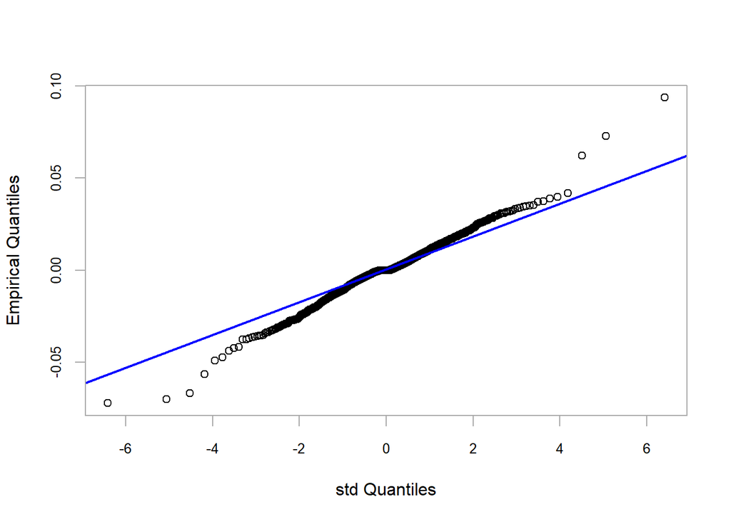

```r
chart.QQPlot(portfRets, distribution = "std", main ="")
```

Zmienność dla modelu(fit_5) uwzględniającego poprawkę wynikającą z warunku t-studenta modelu GARCH(1,1)

```r
vol_5 <- volatility(fit_5) #zmienność dla modelu fit_5
res_fit_5 <- residuals(fit_5, standardize = TRUE) #standaryzowanie reszt
vol <- ts(vol_5, frequency = 252, start = c(2011, 10))
res <- ts(res_fit_5, frequency = 252, start = c(2011, 10))
```

Wykres zmienności zlogarytmowanych stóp zwrotu w badanym przedziale czasowym

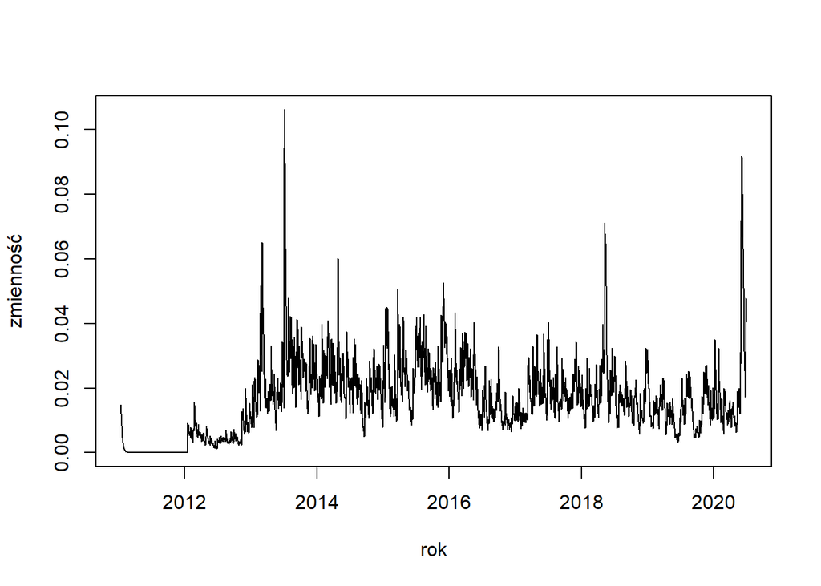

```r
plot(vol, xlab = "rok", ylab = "zmienność", type = "l")
```

wykres zestandaryzowanych reszt po uwzględnieniu warunku t-studenta modelu GARCH(1,1)

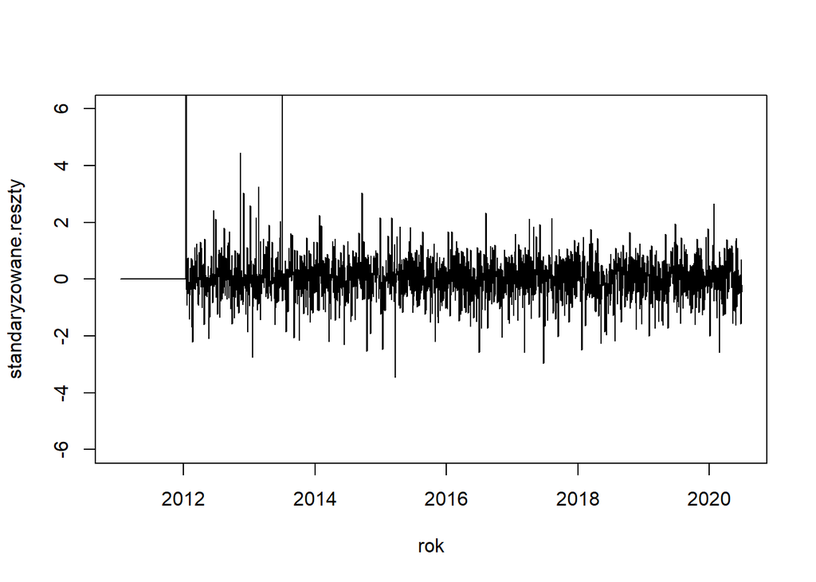

```r
plot(res, xlab = "rok", ylab = "standaryzowane.reszty", type = "l", ylim = c(-6, 6))
```

Predykcja ze zmiennością w tle jako przedział zaufania w 95%

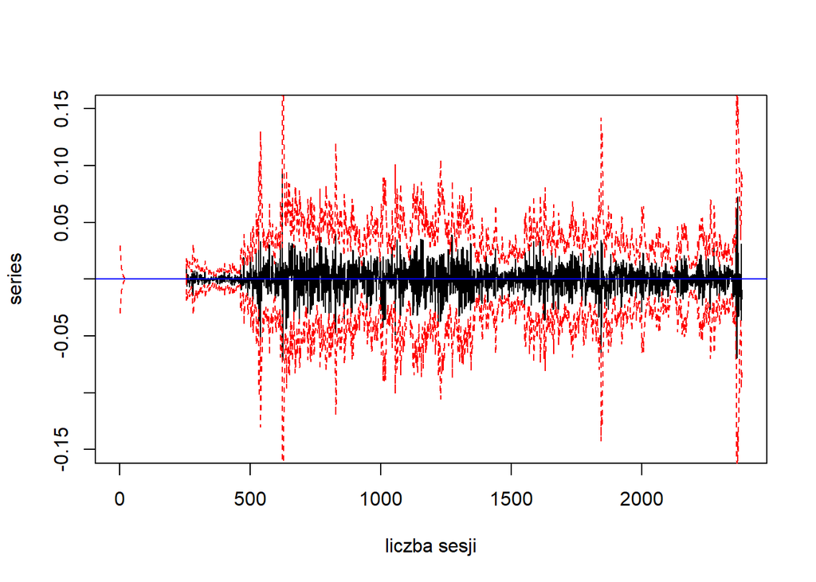

```r
upp <- 1.672e-09 + 2 * vol_5
low <- 1.672e-09 - 2 * vol_5
tdx <- c(1:2385)
plot(tdx, portfRets, xlab = "liczba sesji", ylab = "series", type ="l", ylim = c(-0.15, 0.15))
lines(tdx, upp, lty = 2, col = "red")
lines(tdx, low, lty = 2, col = "red")
abline(h = c(1.672e-09), col = "blue")
```

#Pobieranie danych S&P500 ze strony www.yahoo.com

```r
getSymbols("SPY", from = firstNonZeroDay, to = to)
```

```
## [1] "SPY"
```

zlogarytmowanie oraz zmiana na format *xts*, zlogarytmowanie i przeliczenie na skumulowaną stopę zwrotu

```r
SPYrets <- diff(log(Cl(SPY)))[-1]
cumSPYrets <- cumprod(1 + SPYrets)
```

Połączenie protfela wraz z porównywanymi danymi *cumSPYrets*

```r
comparison <- cbind(cumPortfRets, cumSPYrets)
colnames(comparison)  <- c("strategy", "SPY")
```

Wykres porównania strategii oraz S&P500

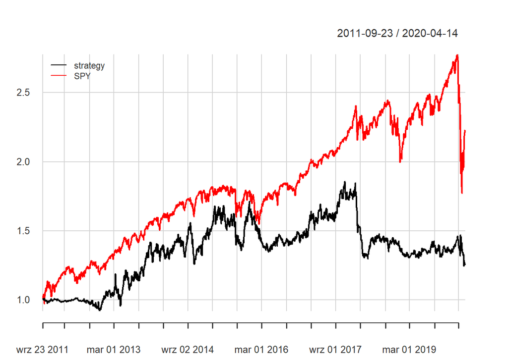

```r
chart.TimeSeries(na.omit(comparison), legend.loc = "topleft",
                 element.color =c("green", "red"))
```

Podsumowanie portfela

```r
SharpeRatio.annualized(portfRets)
```

```
##                                      [,1]
## Annualized Sharpe Ratio (Rf=0%) 0.1325025
```

```r
Return.annualized(portfRets)
```

```
##                         [,1]
## Annualized Return 0.02395746
```

```r
maxDrawdown(portfRets)
```

```
## [1] 0.3284446
```

```r
table_3 <- data.frame(Items = c("Wskaźnik Sharpe annualizowany", "Roczna stopa annualizowana", "maxSpadek kapitału"),
                      Features = c(SharpeRatio.annualized(portfRets) * 100, Return.annualized(portfRets) * 100, maxDrawdown(portfRets) *100))
knitr::kable(table_3, digits = 2)
```

| Items | Features |
| --- | --- |
| Wskaźnik Sharpe annualizowany | 13.25 |
| Roczna stopa annualizowana | 2.40 |
| maxSpadek kapitału | 32.84 |

#Wykres dla ETF_DAX

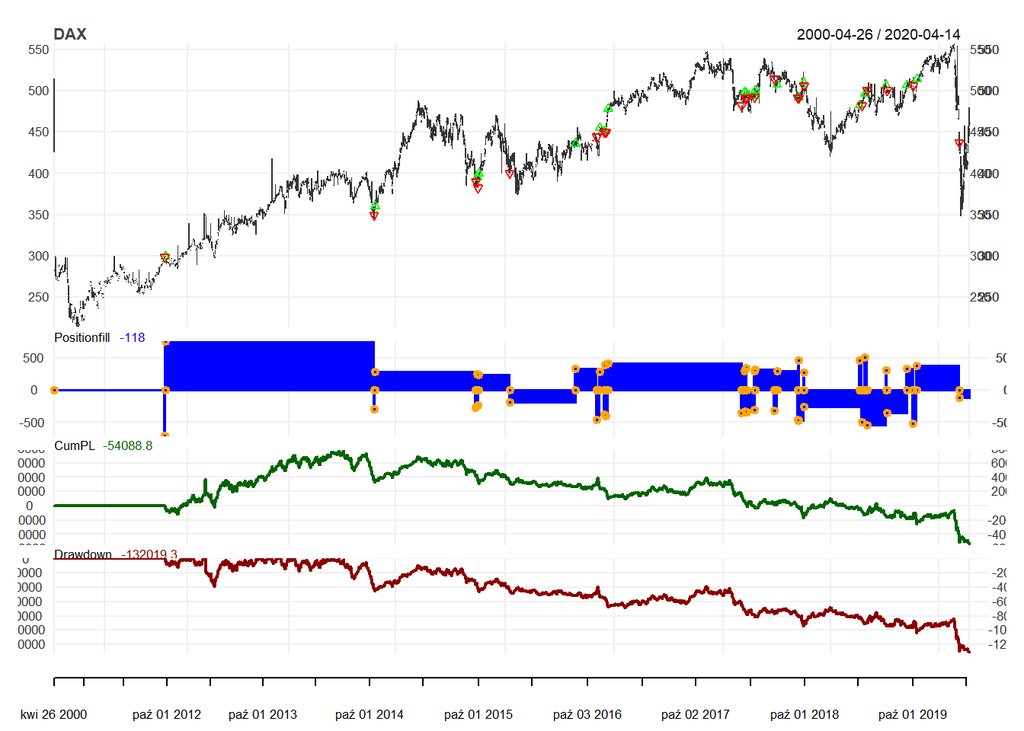

```r
chart.Posn(portfolio.st, "DAX")
```

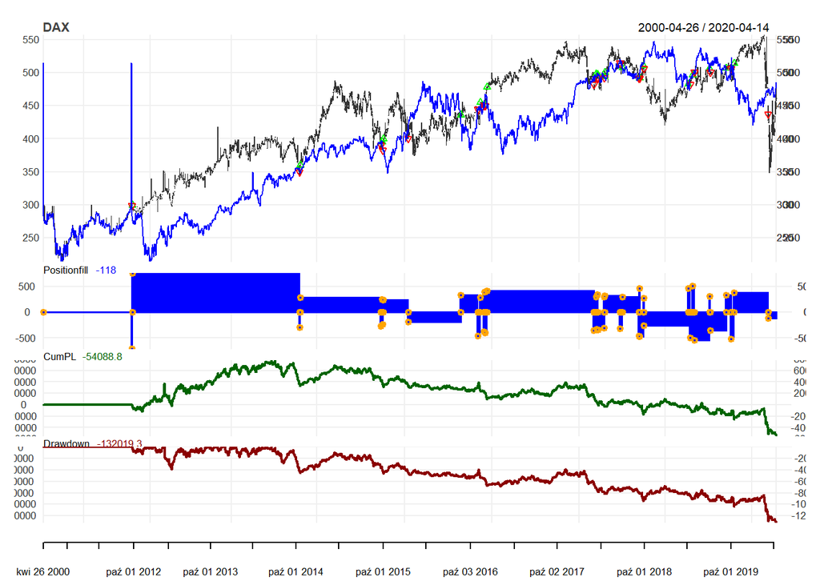

```r
tmp <- namedLag(Cl(DAX), k = nLag)
add_TA(tmp$namedLag, col = "blue", on = 1)
```

#Wykres dla ETF_WIG20

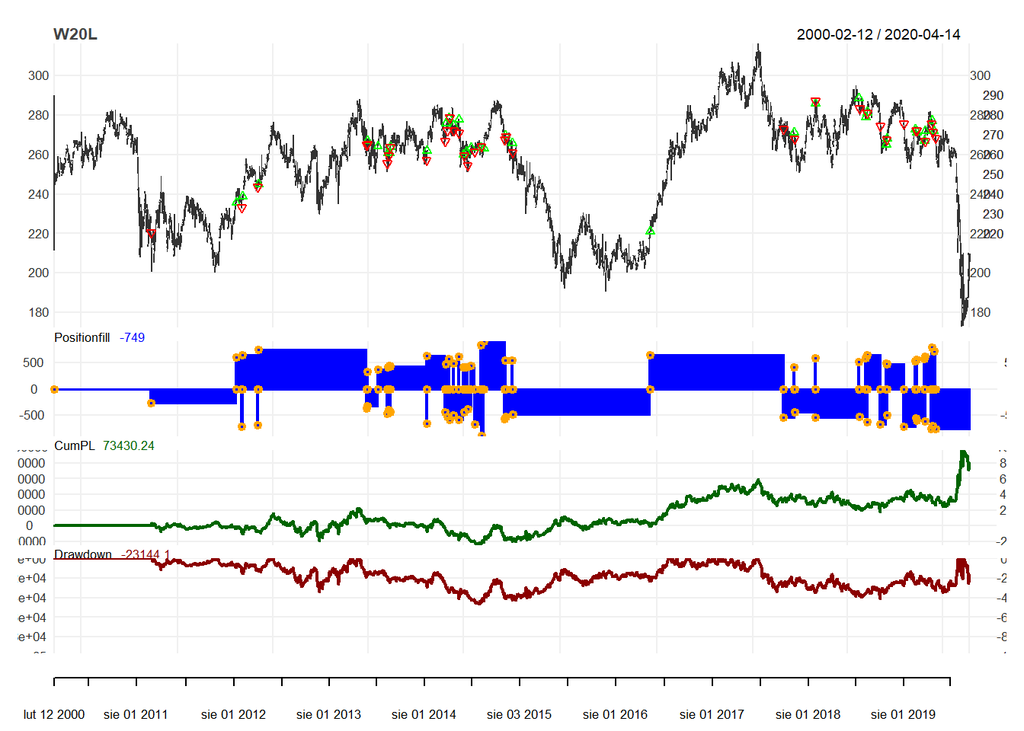

```r
chart.Posn(portfolio.st, "W20L")
```

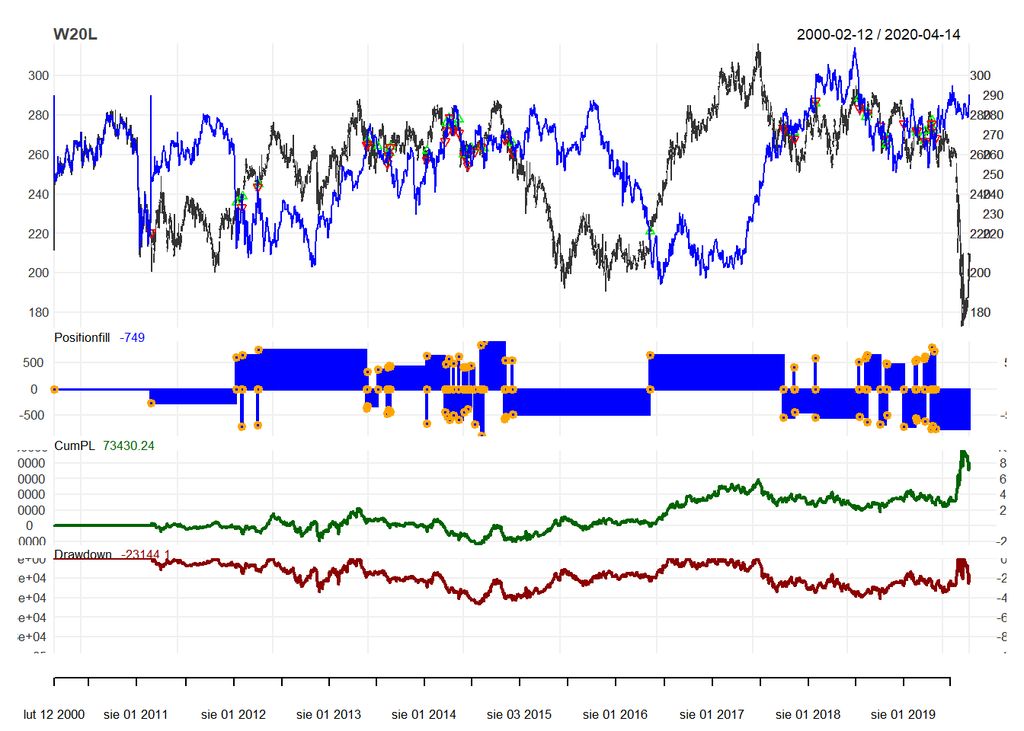

```r
tmp <- namedLag(Cl(W20L), k = nLag)
add_TA(tmp$namedLag, col = "blue", on = 1)
```

#Wykres dla ETF_S&P500

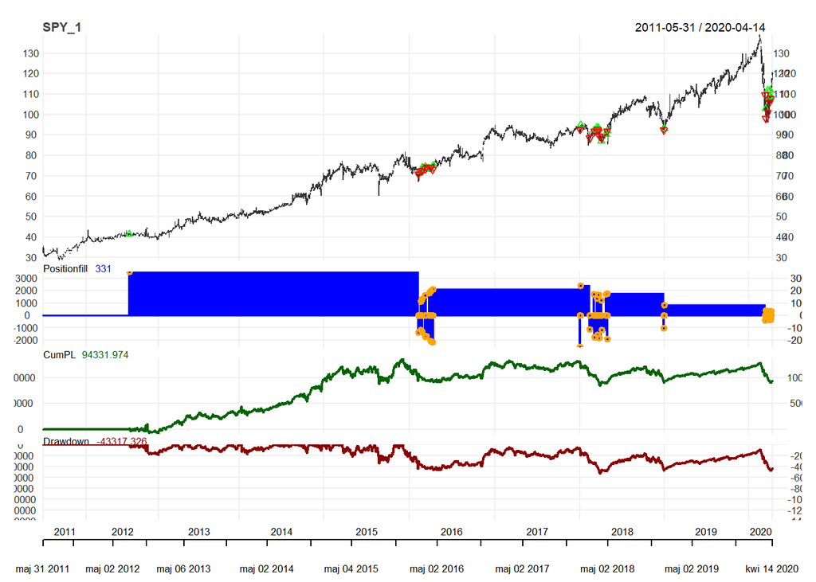

```r
chart.Posn(portfolio.st, "SPY_1")
```

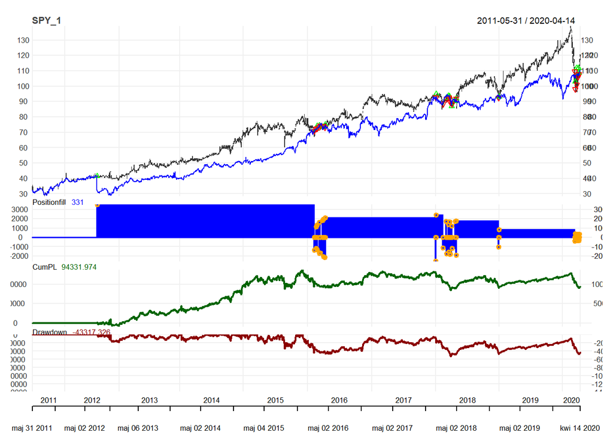

```r
tmp <- namedLag(Cl(SPY_1), k = nLag)
add_TA(tmp$namedLag, col = "blue", on = 1)
```